# **Modelos de regressão I**

Ariane Hayana Thomé de Farias

Prof. Dr. Jhonnata B. de Carvalho

29/11/2020

## **Resumo**

O presente estudo busca analisar as relações entre os critérios apresentados no *World Happiness Report 2020* (Relatório Mundial da Felicidade 2020) com a expectativa de vida saudável ao nascer, que é uma medida do número de anos de boa saúde que um recém-nascido pode esperar. Para tanto, foram ajustados dois modelos de regressão linear múltipla considerando as 153 observações, de modo que, no primeiro modelo ajustado levou-se em consideração as covariáveis *Score da felicidade* e *Pib per capita* e foi possível o ajuste do modelo. Entretanto, este poderia ser melhorado e, desta forma, após uma nova análise foi possível a construção de um novo modelo considerando outras covariáveis para melhor entendermos quais critérios apresentados no *World Happiness Report* (Relatório Mundial da Felicidade) estão melhor relacionados com a variável resposta. Dessa forma, o novo modelo ajustado obtido explica cerca de $81,82\%$ da variação total da expectativa de vida saudável ao nascer.

**Palavras-chave:** *Modelo de regressão linear múltipla. Relatório Mundial da Felicidade. Estatística. Análise de diagnóstico.*

## **1. Introdução**

O conceito sobre felicidade é algo bastante complexo e vem sendo estudado durante anos. Apesar de ser uma temática difícil em tempos de pandemia, em 2020 foi publicado o *World Happiness Report* (Relatório Mundial da Felicidade), que busca mensurar a felicidade considerando os seguintes critérios: (1) PIB per capita; (2) apoio social; (3) expectativa de vida; (4) liberdade para fazer escolhas; (5) generosidade; (6) percepções de corrupção. Este relatório é publicado pela Rede de Soluções para o Desenvolvimento Sustentável da Organização das Nações Unidas (ONU) e em 2020 foi realizada uma pesquisa considerando a percepção de felicidade de 153 países e o resultado do ranking global de felicidade depende, exclusivamente, da avaliação individual das pessoas nos últimos três anos, portanto, a edição de 2020 considera os dados de 2017 a 2019 (Helliwell et al, 2020). Os dados têm sido coletados anualmente pela Gallup, instituição parceira do projeto, reconhecida por auxiliar gestores e líderes com informações estratégicas. [[1]](https://canaldafelicidade.com.br/relatorio-mundial-da-felicidade/) Assim, ao analisarmos os critérios utilizados para a elaboração do Relatório Mundial da Felicidade (2020), surge uma questão importante que pode ser elucidada através da aplicação de um modelo de regressão linear múltipla: Quais critérios estão mais associados à expectativa de vida saudável ao nascer?  
Deste modo, o objetivo deste estudo é aplicar um modelo de regressão linear múltipla que possa responder a tal questionamento e, para tanto, pretende-se:

- Realizar uma análise exploratória dos dados referente a expectativa de vida saudável ao nascer;
- Fazer a seleção do melhor modelo de regressão linear múltipla;
- Prever resultados através de novas observações.

No que se refere à estrutura, este trabalho encontra-se organizado em cinco seções, dispostas da seguinte forma: a primeira trata da introdução, que aborda os principais aspectos do trabalho; a segunda refere-se a definição das variáveis utilizadas; a terceira apresenta os resultados e discussão sobre o estudo; na quarta encontram-se as considerações finais do trabalho e, posteriormente, as referências utilizadas.

## **2. Descrição das variáveis**

De acordo com os autores (Helliwell et al, 2020), as variáveis e suas respectivas descrições são:

| Variável | Descrição |
| --- | --- |
| Score da felicidade | É uma medida que considera os anos de 2005 a 2019 de uma pesquisa que utiliza a média nacional das respostas referentes à qualidade de vida. Usando a escala da escada de Cantril para medir a satisfaçã… |
| Percepções de corrupção | As percepções de corrupção são as médias de respostas binárias a duas perguntas: *“A corrupção está disseminada por todo o governo ou não?”* e *“A corrupção está disseminada dentro das empresas ou não… |
| PIB per capita | O PIB per capita é em termos de Paridade do Poder de Compra (PPC) ajustado para dólares internacionais constantes de 2011, retirado dos Indicadores de Desenvolvimento Mundial (WDI) divulgados pelo Ban… |
| Apoio social | O apoio social é a média nacional das respostas binárias (*0 = não, 1 = sim*) à pergunta: *“Se você está com problemas, você tem parentes ou amigos com quem pode contar para ajudá-lo sempre que você p… |
| Liberdade para fazer escolhas de vida | É a média nacional de respostas binárias à pergunta: *“Você está satisfeito ou insatisfeito com sua liberdade de escolher o que fazer com sua vida?”* |
| Generosidade | É o resíduo da regressão da média nacional de respostas à pergunta: *“Você doou dinheiro para uma instituição de caridade no mês passado?”* no PIB per capita. |
| Expectativa de vida saudável ao nascer | A expectativa de vida saudável ao nascer é uma medida do número de anos de boa saúde que um recém-nascido pode esperar. É baseada nos dados extraídos do repositório de dados do Observatório Global de … |

## **3. Resultados e discussão**

Nesta seção serão apresentados os principais resultados obtidos no que se refere a: (1) análise exploratória dos dados referentes à expectativa de vida saudável ao nascer; (2) o processo de seleção das covariáveis; (3) o ajuste do modelo de regressão; (4) a análise de diagnóstico e; (5) predições realizadas. Neste estudo, a variável dependente $(y)$ será **expectativa de vida saudável ao nascer** e através da seleção das covariáveis serão escolhidas as variáveis independentes $x_i$ que possuam uma melhor associação à variável expectativa de vida $(y)$. Após serem escolhidas tais variáveis, o modelo será ajustado e passará para a etapa seguinte de ajuste de algumas métricas de avaliação.

### **3.1 Análise exploratória**

Neste estudo, a variável *Expectativa de vida saudável ao nascer* será a variável resposta ($y$) adotada no modelo de regressão linear múltipla e, deste modo, para melhor compreensão das estatísticas relacionadas a esta variável, nesta seção serão abordadas as principais características sobre a variável supracitada.

Para a análise exploratória dos dados é possível visualizarmos abaixo o histograma da variável resposta e suas respectivas frequências:

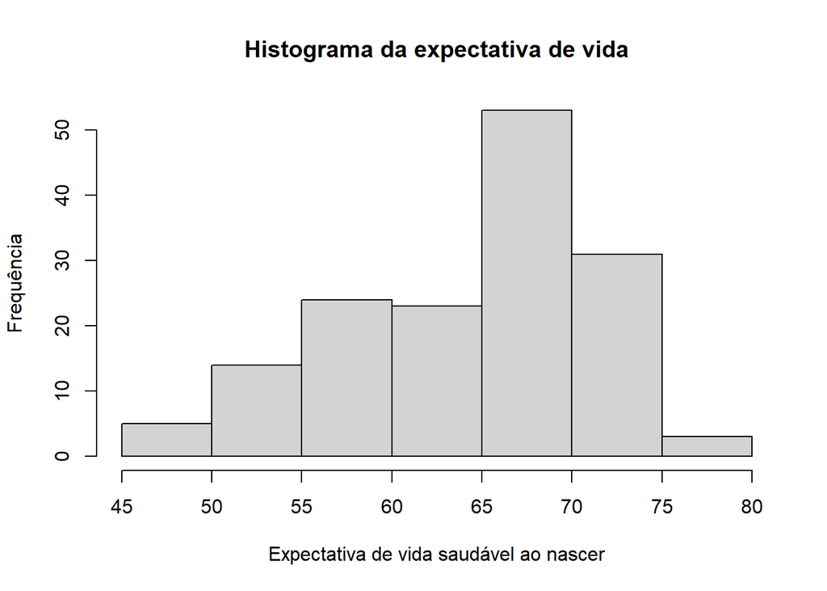

```r
# Leitura dos dados
dados = read.table("expectativa2020.csv", header = TRUE, sep = ",")

# 5 variáveis retiradas
dados = dados[,-c(1:2,13,16,20)]

expectativa.de.vida.saudavel = dados[,7]

hist(expectativa.de.vida.saudavel,xlab ="Expectativa de vida saudável ao nascer",ylab ="Frequência", main ="Histograma da expectativa de vida")
```

Com relação a variável **expectativa de vida saudável ao nascer**, pode-se analisar as seguintes informações:

```r
summary(expectativa.de.vida.saudavel)
```

```
##    Min. 1st Qu.  Median    Mean 3rd Qu.    Max.
##   45.20   58.96   66.31   64.45   69.29   76.80
```

A expectativa de vida saudável ao nascer é uma medida do número de anos de boa saúde que um recém-nascido pode esperar. Assim, conforme os resultados obtidos, nas *153* observações desta variável nota-se que, a expectativa mínima corresponde a 45,20 anos e a máxima de 76,80 anos. Quando analisamos a média, nota-se que a expectativa média é 64,45 anos e a mediana 66,31 anos. Para o primeiro quartil, temos 58,96 anos e para o terceiro quartil, esta corresponde a 69,29 anos. É possível visualizarmos graficamente estas informações através do diagrama de caixa (*box plot*):

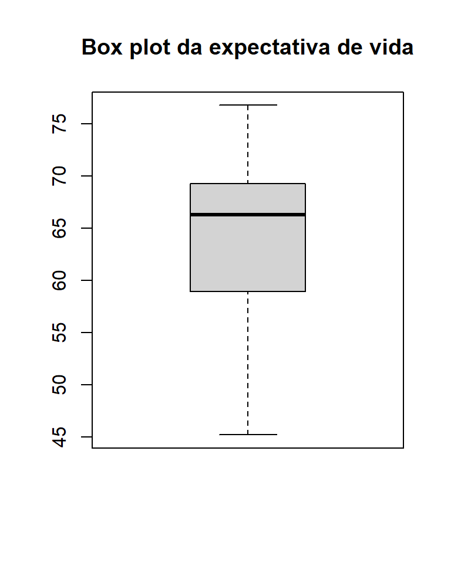

```r
boxplot(expectativa.de.vida.saudavel, main ="Box plot da expectativa de vida")
```

Assim, podemos visualizar que a linha inferior da caixa indica o valor do primeiro quartil da variável (*58,96*), a linha superior da caixa indica o terceiro quartil (*69,29*). A altura da caixa indica a distância interquartil (DIQ), que representa a diferença entre o terceiro e o primeiro quartil, que neste caso será *10,33*. Uma terceira linha horizontal, a mediana (igual a *66,31*), divide a caixa em duas partes e a posição da linha da mediana é próxima ao terceiro quartil, o que evidencia uma assimetria negativa nos dados estudados, além disso, podemos afirmar que não há presença de outliers para esta variável.

Verificou-se também a correlação existente entre as variáveis e através do diagrama a seguir é possível visualizar a correlação das variáveis independentes com a variável resposta:

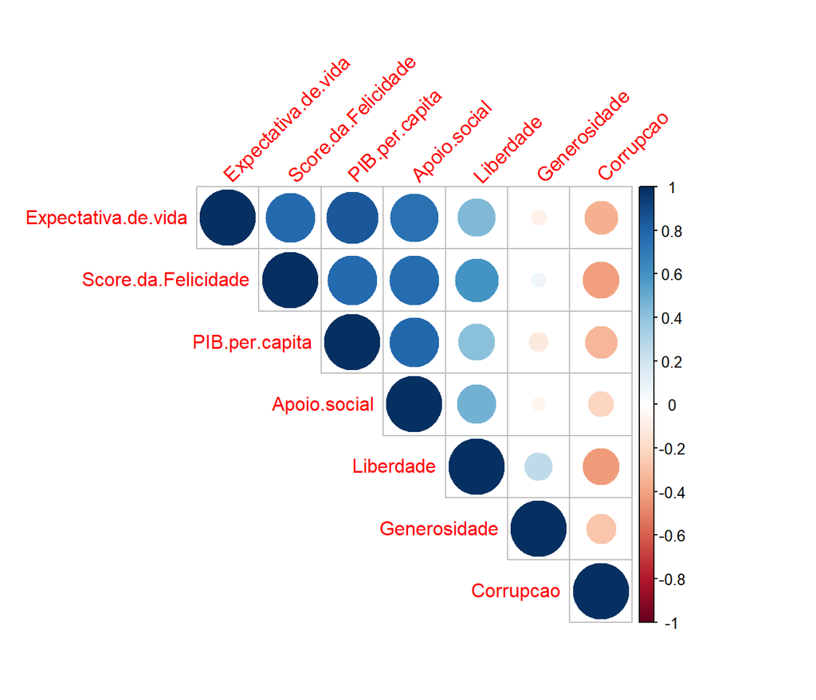

```r
# Atribuição de variáveis
y = dados$Healthy.life.expectancy
v1 = dados$Ladder.score
v2 = dados$Logged.GDP.per.capita
v3 = dados$Social.support
v4 = dados$Freedom.to.make.life.choices
v5 = dados$Generosity
v6 = dados$Perceptions.of.corruption

result = data.frame(Expectativa.de.vida=y, Score.da.Felicidade = v1, PIB.per.capita=v2, Apoio.social = v3, Liberdade=v4, Generosidade=v5, Corrupcao=v6)

# Correlação entre variáveis
cor_dados = cor(result)
corrplot(cor_dados,type="upper",tl.srt=45,tl.cex = 1)
```

Conforme podemos observar, as variáveis *Score de felicidade*, *PIB per capita*, *Apoio social* são as mais correlacionadas com a variável reposta *Expectativa de vida saudável ao nascer*.

Para verificarmos quanto uma variável é afetada pela outra, é possível visualizarmos os gráficos de dispersão das variáveis independentes mais a variável resposta:

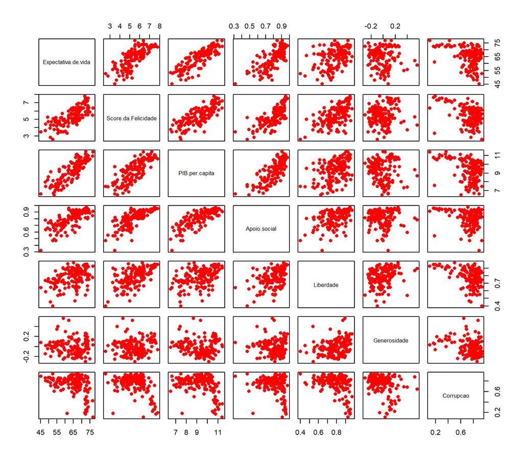

```r
# Grafico bidimensional

result = data.frame(Expectativa.de.vida=y, Score.da.Felicidade = v1, PIB.per.capita=v2, Apoio.social = v3, Liberdade=v4, Generosidade=v5, Corrupcao=v6)

pairs(result, pch=16, col="red", cex=1)
```

Assim, o gráfico sugere uma relação positiva entre as variáveis *Score de felicidade*, *PIB per capita*, *Apoio social*, *Liberdade para fazer escolhas de vida* com *Expectativa de vida saudável ao nascer*, pois quando o valor de $x_i$ aumenta o valor de $y$ tende a aumentar. Podemos também visualizar os valores de tais correlações através da matriz de correlação:

```r
# Correlação entre as variáveis
# Tabela
result = data.frame(Expectativa=y, Felicidade = v1, PIB=v2, Apoio.social = v3, Liberdade=v4, Generosidade=v5, Corrupcao=v6)

# Correlação entre variáveis
cor_dados = cor(result)
cor_dados = round(cor_dados,5)
datatable(cor_dados)
```

|  | Expectativa | Felicidade | PIB | Apoio.social | Liberdade | Generosidade | Corrupcao |
| --- | --- | --- | --- | --- | --- | --- | --- |
| Expectativa | 1 | 0.77032 | 0.84847 | 0.74274 | 0.44885 | -0.07185 | -0.35384 |
| Felicidade | 0.77032 | 1 | 0.77537 | 0.765 | 0.5906 | 0.06904 | -0.41831 |
| PIB | 0.84847 | 0.77537 | 1 | 0.78181 | 0.41902 | -0.1184 | -0.33473 |
| Apoio.social | 0.74274 | 0.765 | 0.78181 | 1 | 0.47886 | -0.05678 | -0.21053 |
| Liberdade | 0.44885 | 0.5906 | 0.41902 | 0.47886 | 1 | 0.25372 | -0.42014 |
| Generosidade | -0.07185 | 0.06904 | -0.1184 | -0.05678 | 0.25372 | 1 | -0.27848 |
| Corrupcao | -0.35384 | -0.41831 | -0.33473 | -0.21053 | -0.42014 | -0.27848 | 1 |

Através dos resultados obtidos na matriz de correlação, podemos afirmar que as variáveis *Score de felicidade*, *PIB per capita*, *Apoio social*, *Liberdade para fazer escolhas de vida* apresentam uma direção da associação positiva com *Expectativa de vida saudável ao nascer* e as variáveis *Generosidade* e *Percepções de corrupção* apresentam uma direção da associação negativa. As variáveis *Score de felicidade*, *PIB per capita* e *Apoio social* são as que apresentam uma correlação positiva forte com a variável resposta ( $> 0,7$).

### **3.2 Procedimentos metodológicos e seleção de covariáveis**

Para a seleção de covariáveis fez-se, incialmente, uma análise de correlação considerando todas as variáveis disponíveis no banco de dados referentes ao *World Happiness Report (2020)*. Após esta etapa, selecionou-se a variável resposta *Expectativa de vida saudável ao nascer* ($y$) e, considerando o grande volume de covariáveis, foi necessária a utilização de um critério para a seleção do modelo para verificar se a contribuição das variáveis era significativa. Desta forma, optou-se pelo método automático de seleção de modelos denominado *Stepwise*. Assim, considerando um nível de significância $\alpha = 5$%, verificou-se as variáveis que apresentaram no passo anterior a maior correlação com a variável resposta para verificar se os parâmetros eram significativos com base na estatística F.

Após o ajuste de diversos modelos, considerando $x_1 =$ *Score da felicidade* e $x_5 =$ *Pib per capita*, selecionou-se o modelo de regressão linear múltipla ajustado e obteve-se os seguintes resultados:
$$\widehat{y}=20,2629+1,7890felicidade_{i}+3,6997pib_{i}$$
Onde:
$b_0 = 20,2629$
$b_1 = 1,7890$
$b_2 = 3,6997$

Outras informações relevantes sobre o modelo ajustado são apresentadas a seguir:

```r
# Leitura dos dados
dados = read.table("expectativa2020.csv", header = TRUE, sep = ",")

# Colunas retiradas:
# [1] "Country.name"
# [2] "Regional.indicator"
# [13] "Ladder.score.in.Dystopia"
# [16] "Explained.by..Healthy.life.expectancy"
# [20] "Dystopia...residual"

# 5 variáveis retiradas
dados = dados[,-c(1:2,13,16,20)]

colnames(dados)<-c(paste("x",1:6,sep=""),"y",paste("x",7:14,sep=""))

attach(dados)

modelo1 = lm(y~x1+x5,data=dados)

# Número de observações do modelo
n=dim(dados)[1]

# Número de parâmetros - B0, B1 e B2
p=2+1

# Bonferroni
alphaBonf = 0.05/3

# Modelo ajustado
ajuste = modelo1
summary(ajuste)
```

```
##
## Call:
## lm(formula = y ~ x1 + x5, data = dados)
##
## Residuals:
##      Min       1Q   Median       3Q      Max
## -10.6807  -1.9446   0.1643   2.4817   6.7924
##
## Coefficients:
##             Estimate Std. Error t value Pr(>|t|)
## (Intercept)  20.2629     2.2933   8.836 2.47e-15 ***
## x1            1.7890     0.4089   4.375 2.26e-05 ***
## x5            3.6997     0.3785   9.774  < 2e-16 ***
## ---
## Signif. codes:  0 '***' 0.001 '**' 0.01 '*' 0.05 '.' 0.1 ' ' 1
##
## Residual standard error: 3.541 on 150 degrees of freedom
## Multiple R-squared:  0.7516, Adjusted R-squared:  0.7483
## F-statistic: 226.9 on 2 and 150 DF,  p-value: < 2.2e-16
```

É possível verificar que estamos considerando no modelo *três parâmetros* ($\beta_0$, $\beta_1$ e $\beta_2$) com um tamanho $n = 153$ observações e, considerando as estimativas encontradas, podemos afirmar que:

- $b_0$: Estima-se que, em média, quando o *score no ranking da felicidade* e o *PIB per capita* são iguais a zero, a *expectativa de vida saudável ao nascer* é igual a $20,2629$;
- $b_1$: Fixando o *PIB per capita*, estima-se que, em média, para cada aumento em uma unidade do *score no ranking da felicidade*, há um aumento de $1,7890$ *expectativa de vida saudável ao nascer*;
- $b_2$: Fixando o *score no ranking da felicidade*, estima-se que, em média, para cada aumento em uma unidade no *PIB per capita*, há um aumento de $3,6997$ *expectativa de vida saudável ao nascer*.

Para realizarmos uma predição de novas observações, vamos considerar as novas observações como sendo $x_1 = 1$ e $x_5 = 6$. Desse modo, considerando um intervalo de confiança de $95\%$ para a estimativa, obteremos os seguintes resultados:

```r
# x1 - [1] "Ladder.score"
# x5 - [5] "Logged.GDP.per.capita"

modelo1 = lm(y~x1+x5,data=dados)

X<-cbind(1,x1,x5)

X_m<-solve(t(X)%*%X)

Y<-y

b_chap<-solve(t(X)%*%X)%*%t(X)%*%Y

B<-summary(modelo1)

alpha<-0.05
p = 3
n<-length(y)
t_c<-qt(1-alpha/2,n-p)

x0<-c(1,1,6)

Y_0 = sum(coef(modelo1)*x0);Y_0
```

```
## [1] 44.24982
```

```r
c(44.24982-t_c*sqrt((B$sigma^2)*(1+t(x0)%*%X_m%*%x0)),
  44.24982+t_c*sqrt((B$sigma^2)*(1+t(x0)%*%X_m%*%x0)))
```

```
## [1] 36.86089 51.63875
```

$$IC(95\%) = [36,86089; 51,63875]$$
Desta forma, se o estudo fosse repetido $1000$ vezes e fossem calculados $1000$ intervalos de confiança (um para cada estudo) com nível de confiança de $95\%$, em média, espera-se que $950$ desses intervalos irão conter o verdadeiro valor do parâmetro.

Por outro lado, conforme podemos observar também, o teste F resulta em um p-valor $< 2,2e^{-16}$, ou seja, pelo menos um parâmetro regressor é diferente de zero. Assim podemos detectar se há indícios de multicolinearidade através de uma medida de fator de inflação da variância (*Variance Inflation Factor - VIF*). Nesse sentido, utilizando os dados deste estudo, temos que a VIF será:

```r
mult = vif(modelo1);mult
```

```
##       x1       x5
## 2.507557 2.507557
```

Também é necessário verificar o gráfico bidimensional das covariáveis para visualizarmos se as estimativas para os coeficientes da regressão estão com sinais contrários em comparação com o sinais esperados no gráfico bidimensional. Assim, é possível visualizarmos graficamente se ocorre este comportamento:

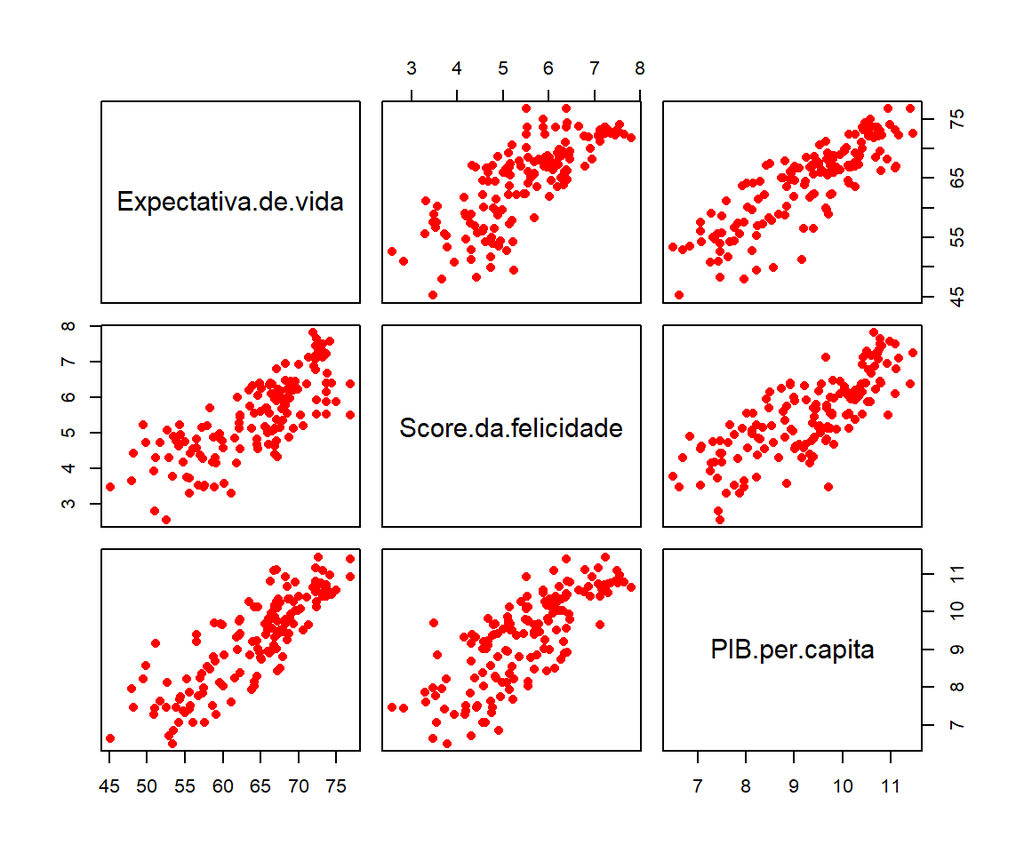

```r
dados1 = data.frame(Expectativa.de.vida=y,Score.da.felicidade=x1,
                    PIB.per.capita=x5)

# Grafico bidimensional
pairs(dados1, pch=16, col="red", cex=1)
```

O gráfico sugere uma correlação linear positiva entre as variáveis e, desta forma, podemos concluir que não há indícios de que exista multicolinearidade com os dados avaliados pois todos os resultados deram abaixo de 10, bem como não há estimativas para os coeficientes da regressão com sinais contrários em comparação com os sinais esperados visualizados através do gráfico de dispersão.

Considerando o modelo estudado, para o **teste de significância** leva-se em consideração, sob $H_0$, o teste de hipóteses dado $l = 0, 1, ... ,k$:

$$\\ H_0: \beta_l = 0$$

$$\\ H_1: \beta_l \neq 0$$

Considerando um nível de significância de 5%, os parâmetros do modelo são **todos** significativos $(< 0,05)$, ao passo que:

> p-valor = $2,47e-15 < 0,05 = α$

> p-valor = $2,26e-05 < 0,05 = α$

> p-valor = $2e-16 < 0,05 = α$

A mesma interpretação é válida caso considerássemos o nível de significância corrigido de Bonferroni (nível de significância real igual a $\alpha^* = 0,01666667$).

Ao analisarmos o coeficiente de determinação ($R^2$), o modelo ajustado explica cerca de $75,16\%$ da variação total da variável *Expectativa de vida saudável ao nascer* ($y$). Também nota-se o resultado do $R^2$ *ajustado*, que representa a porcentagem de variação na resposta que é explicada pelo modelo, ajustada através do número de preditores do modelo em relação ao número de observações, que neste caso foi igual a $74,83\%$.

### **3.3.1 Análise de diagnóstico**

### **3.3.1.1 Resíduos Padronizados Externamente (RPE)**

Inicialmente, fez-se a representação gráfica com o comportamento dos resíduos padronizados externamente (RPE) *versus* os índices:

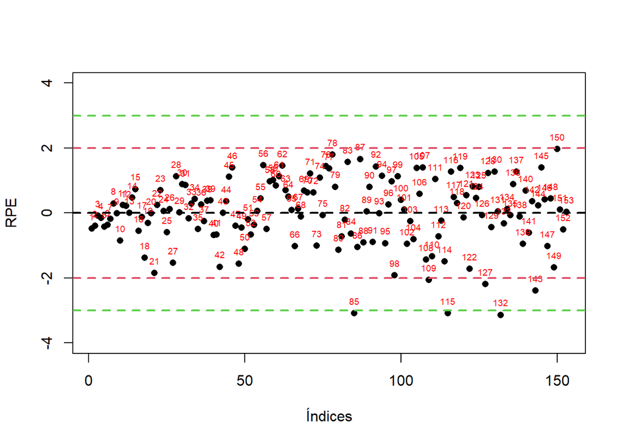

```r
# Análise dos resíduos
modelo1 = lm(y~x1+x5,data=dados)
ajuste = modelo1

rpe<-rstudent(ajuste)

plot(rpe,pch=16,xlab="Índices",ylab="RPE",ylim=c(-4,4))
text(rpe,row.names(1:n),cex=0.6, pos=3,col="red")
abline(h=c(0,-2,2,-3,3),col=c(1,2,2,3,3),lty=2,lwd=2)
```

Podemos observar o comportamento dos resíduos no gráfico acima, que aparentemente estão distribuídos em torno do zero de forma aleatória e é notória a presença de **três** pontos fora das faixas tracejadas dos limites: `[85]`, `[115]` e `[132]`.

Considerando que, conforme demonstrado anteriormente, existem *três* observações que podem ser outliers, é importante quantificarmos a influência destes nas estimativas do modelo e, para isso, calcula-se a variação percentual de cada estimativa dos coeficientes do modelo (sem o ponto observado) com relação às estimativas do modelo completo ajustado. Desta forma, foram calculadas as variações percentuais removendo cada observação que foi identificada e foi feita a comparação dos impactos causados por essa remoção nas inferências dos parâmetros, obtendo-se os seguintes resultados:

```r
ajuste = modelo1

VariacaoPercentual_RPE1 <- function(){

# Removendo a observação [85]
mod1<-lm(y~x1+x5,subset=c(1:84,86:n),data=dados)
m1 = summary(mod1)
r2_m1 = m1$r.squared
vp1 = 100*((coef(mod1)-coef(ajuste))/coef(ajuste))

# Removendo a observação [115]
mod2<-lm(y~x1+x5,subset=c(1:114,116:n),data=dados)
m2 = summary(mod2)
r2_m2 = m2$r.squared
vp2 = 100*((coef(mod2)-coef(ajuste))/coef(ajuste))

# Removendo a observação [132]
mod3<-lm(y~x1+x5,subset=c(1:131,133:n),data=dados)
m3 = summary(mod3)
r2_m3 = m3$r.squared
vp3 = 100*((coef(mod3)-coef(ajuste))/coef(ajuste))


b_0 = c(vp1[[1]],vp2[[1]],vp3[[1]])
b_1 = c(vp1[[2]],vp2[[2]],vp3[[2]])
b_2 = c(vp1[[3]],vp2[[3]],vp3[[3]])
observacao = c("85", "115", "132")
R_2 = c(r2_m1,r2_m2,r2_m3)
variacao = c(vp1,vp2,vp3)

vp_comparacao = list(Resultados = data.frame(observacao,Var_b0=b_0,Var_b1=b_1,Var_b2=b_2,R_2))

return(vp_comparacao)
}
VariacaoPercentual_RPE1()
```

```
## $Resultados
##   observacao     Var_b0    Var_b1     Var_b2       R_2
## 1         85  3.1902335  4.219739 -2.8773837 0.7593983
## 2        115  1.7545016 -1.856030 -0.3022089 0.7597416
## 3        132 -0.2654739 -8.705997  2.8427032 0.7614278
```

> Conclusão: Conclui-se que a variação percentual em comparação com o modelo ajustado não é expressiva para os pontos identificados, bem como suas inferências não mudam após a remoção de cada uma das observações e os parâmetros continuam significativos.

Também podemos visualizar o comportamento através da comparação entre o RPE *versus* as variáveis independentes, bem como o gráfico que relaciona o RPE *versus* os valores preditos:

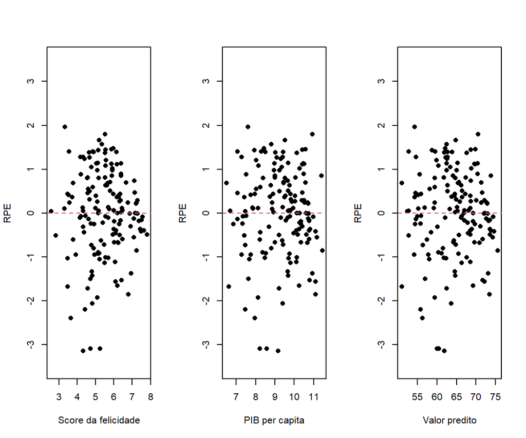

```r
# Comparativo
par(mfrow=c(1,3))
plot(x1,rpe,xlab="Score da felicidade",ylab="RPE",pch=16,ylim=c(-3.5,3.5))
abline(h=0,col=2,lty=2)
plot(x5,rpe,xlab="PIB per capita",ylab="RPE",pch=16,ylim=c(-3.5,3.5))
abline(h=0,col=2,lty=2)
# Resíduos x valor predito
plot(ajuste$fitted,rpe,ylab="RPE",xlab="Valor predito",pch=16,ylim=c(-3.5,3.5))
abline(h=0,col=2,lty=2)
```

Ao analisarmos o comparativo entre os gráficos, é possível verificar que há um indicativo de que o comportamento dos resíduos não é o desejável, tendo em vista que há um certo padrão na distribuição dos pontos, tanto no gráfico que relaciona os resíduos *versus* as variáveis independentes, quanto no gráfico que relaciona os resíduos *versus* os valores preditos. Portanto, é importante verificarmos se as **variâncias do resíduos são homogêneas** e, para isso, utiliza-se o **Teste Goldfeld-Quandt**.

Neste teste serão consideradas as seguintes hipóteses, sob $H_0$:

$$\\ H_0: {\sigma^2_1}={\sigma^2_2}$$

$$\\ H_1: {\sigma^2_1}<{\sigma^2_2}$$

Considerando que $n=153$, o número de observações centrais removidas para a realização do teste será igual a $20\%$, então, $c_i = 0,2 * 153$, ou seja, $30,6$, a qual arredondaremos para $31$. Utilizou-se como base para identificar a heterocedasticidade a variável $x_5$ = *Pib per capita*, sendo esta utilizada para ordenar os dados. Assim, os resultados obtidos no teste serão:

```r
n <-length(y)
c1 = n*0.2

# Considerando a variável x5
gqtest(ajuste,fraction=31,order.by = x5)
```

```
##
##  Goldfeld-Quandt test
##
## data:  ajuste
## GQ = 0.48402, df1 = 58, df2 = 58, p-value = 0.9968
## alternative hypothesis: variance increases from segment 1 to 2
```

Segundo o resultado obtido, considerando um nível de significância $α=0,05$, a hipótese nula não é rejeitada ($p−valor=0,9968 > 0,05=α$), assim, podemos afirmar que as variâncias dos resíduos são homogêneas, portanto, o **modelo apresenta homocedasticidade**.

Para verificar se existe algum tipo de **correlação (autocorrelação)** nos resíduos utiliza-se o **Teste de Durbin-Watson**.

```r
dwtest(ajuste)
```

```
##
##  Durbin-Watson test
##
## data:  ajuste
## DW = 1.9509, p-value = 0.3466
## alternative hypothesis: true autocorrelation is greater than 0
```

Considerando um nível de significância $α = 0,05$, nota-se que $p−valor=0,3466>0,05=α$, portanto, não rejeitamos a hipótese nula e consequentemente não existe autocorrelação, portanto, podemos afirmar que com um nível de confiança de 95%, os **resíduos não são autocorrelacionados**.

### **3.3.1.2 Pontos de alavanca**

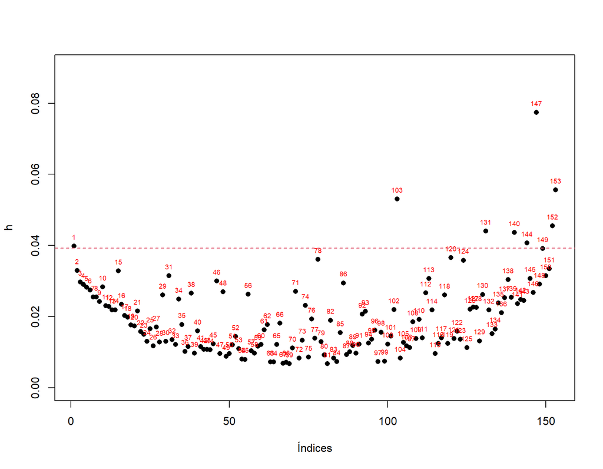

```r
h<-lm.influence(ajuste)$hat
plot(h,pch=16, xlab="Índices",ylim=c(0,0.09))
text(h,row.names(1:n),cex=0.6, pos=3,col="red")
abline(h=2*(p/n),lty=2,col=2)     # h = 0.03921569
```

> Conclusão: As observações 1, 103, 131, 140, 144, 147, 152, 153 podem ser pontos de alavanca

Considerando que, conforme demonstrado anteriormente, existem **oito** observações que podem ser pontos de alavanca, é importante quantificarmos a influência destes nas estimativas do modelo e, para isso, calcula-se a variação percentual de cada estimativa dos coeficientes do modelo (sem o ponto de alavanca observado) com relação às estimativas do modelo completo ajustado. Desta forma, foram calculadas as variações percentuais removendo cada observação que foi identificada e foi feita a comparação dos impactos causados por essa remoção nas inferências dos parâmetros, obtendo-se os seguintes resultados:

```r
ajuste = modelo1

VariacaoPercentual_Alavanca1 <- function(){

# Removendo a observação [1]
mod1<-lm(y~x1+x5,subset=c(2:n),data=dados)
m1 = summary(mod1)
r2_m1 = m1$r.squared
vp1 = 100*((coef(mod1)-coef(ajuste))/coef(ajuste))

# Removendo a observação [103]
mod2<-lm(y~x1+x5,subset=c(1:102,104:n),data=dados)
m2 = summary(mod2)
r2_m2 = m2$r.squared
vp2 = 100*((coef(mod2)-coef(ajuste))/coef(ajuste))

# Removendo a observação [131]
mod3<-lm(y~x1+x5,subset=c(1:130,132:n),data=dados)
m3 = summary(mod3)
r2_m3 = m3$r.squared
vp3 = 100*((coef(mod3)-coef(ajuste))/coef(ajuste))

# Removendo a observação [140]
mod4<-lm(y~x1+x5,subset=c(1:139,141:n),data=dados)
m4 = summary(mod4)
r2_m4 = m4$r.squared
vp4 = 100*((coef(mod4)-coef(ajuste))/coef(ajuste))

# Removendo a observação [144]
mod5<-lm(y~x1+x5,subset=c(1:143,145:n),data=dados)
m5 = summary(mod5)
r2_m5 = m5$r.squared
vp5 = 100*((coef(mod5)-coef(ajuste))/coef(ajuste))

# Removendo a observação [147]
mod6<-lm(y~x1+x5,subset=c(1:146,148:n),data=dados)
m6 = summary(mod6)
r2_m6 = m6$r.squared
vp6 = 100*((coef(mod6)-coef(ajuste))/coef(ajuste))

# Removendo a observação [152]
mod7<-lm(y~x1+x5,subset=c(1:151,153:n),data=dados)
m7 = summary(mod7)
r2_m7 = m7$r.squared
vp7 = 100*((coef(mod7)-coef(ajuste))/coef(ajuste))

# Removendo a observação [153]
mod8<-lm(y~x1+x5,subset=c(1:152),data=dados)
m8 = summary(mod8)
r2_m8 = m8$r.squared
vp8 = 100*((coef(mod8)-coef(ajuste))/coef(ajuste))


b_0 = c(vp1[[1]],vp2[[1]],vp3[[1]],vp4[[1]],vp5[[1]],vp6[[1]],vp7[[1]],vp8[[1]])
b_1 = c(vp1[[2]],vp2[[2]],vp3[[2]],vp4[[2]],vp5[[2]],vp6[[2]],vp7[[2]],vp8[[2]])
b_2 = c(vp1[[3]],vp2[[3]],vp3[[3]],vp4[[3]],vp5[[3]],vp6[[3]],vp7[[3]],vp8[[3]])
observacao = c("1", "103", "131", "140", "144", "147", "152", "153")
R_2 = c(r2_m1,r2_m2,r2_m3,r2_m4,r2_m5,r2_m6,r2_m7,r2_m8)
variacao = c(vp1,vp2,vp3,vp4,vp5,vp6,vp7,vp8)

vp_comparacao = list(Resultados = data.frame(observacao,Var_b0=b_0,Var_b1=b_1,Var_b2=b_2,R_2))

return(vp_comparacao)
}
VariacaoPercentual_Alavanca1()
```

```
## $Resultados
##   observacao        Var_b0      Var_b1      Var_b2       R_2
## 1          1 -0.2477231622  1.80267245 -0.33377683 0.7501472
## 2        103  0.5807600561  0.81038170 -0.55565364 0.7476834
## 3        131 -0.1045398216 -0.08695717  0.08320712 0.7471211
## 4        140 -1.5883467448 -0.57803570  1.05347070 0.7482870
## 5        144 -0.0007131638  1.00456235 -0.30181002 0.7510989
## 6        147 -0.8907197350 -6.46473595  2.43733853 0.7523392
## 7        152  0.5936315344 -1.81969889  0.20364434 0.7459276
## 8        153 -0.0383339040  0.15679253 -0.02456882 0.7468712
```

> Conclusão: Conclui-se que a variação percentual em comparação com o modelo ajustado não é expressiva para os pontos identificados, bem como suas inferências não mudam após a remoção de cada uma das observações e os parâmetros continuam significativos.

### **3.3.1.3 Pontos de influência: Distância de Cook**

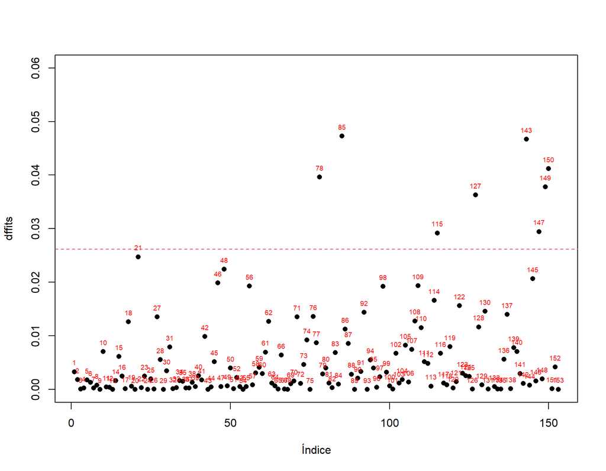

```r
# Distância de Cook
D_Cook = cooks.distance(ajuste)
plot(D_Cook,pch=16,xlab="Índice", ylab="dffits",ylim = c(0,0.06))
text(D_Cook,row.names(1:n),cex=0.6, pos=3,col="red")
abline(h=4/n, lty=2,col=2)   # h = 0.02614379
```

> Conclusão: Identificamos que as observações 78, 85, 115, 127, 143, 147, 149, 150 são pontos influentes pela Distância de Cook. Ressalta-se que as observações 85 e 115 também foram identificadas como outliers.

Considerando que, conforme demonstrado anteriormente, existem **oito** observações que podem ser pontos influentes pela Distância de Cook, é importante quantificarmos a influência destes nas estimativas do modelo e, para isso, calcula-se a variação percentual de cada estimativa dos coeficientes do modelo (sem o ponto de influência observado) com relação às estimativas do modelo completo ajustado. Desta forma, foram calculadas as variações percentuais removendo cada observação que foi identificada e foi feita a comparação dos impactos causados por essa remoção nas inferências dos parâmetros, obtendo-se os seguintes resultados:

```r
VariacaoPercentual_Cook <- function(){

  # Removendo a observação [78]
  mod1<-lm(y~x1+x5,subset=c(1:77,79:n),data=dados)
  m1 = summary(mod1)
  r2_m1 = m1$r.squared
  vp1 = 100*((coef(mod1)-coef(ajuste))/coef(ajuste))

  # Removendo a observação [85]
  mod2<-lm(y~x1+x5,subset=c(1:84,86:n),data=dados)
  m2 = summary(mod2)
  r2_m2 = m2$r.squared
  vp2 = 100*((coef(mod2)-coef(ajuste))/coef(ajuste))

  # Removendo a observação [115]
  mod3<-lm(y~x1+x5,subset=c(1:114,116:n),data=dados)
  m3 = summary(mod3)
  r2_m3 = m3$r.squared
  vp3 = 100*((coef(mod3)-coef(ajuste))/coef(ajuste))

  # Removendo a observação [127]
  mod4<-lm(y~x1+x5,subset=c(1:126,128:n),data=dados)
  m4 = summary(mod4)
  r2_m4 = m4$r.squared
  vp4 = 100*((coef(mod4)-coef(ajuste))/coef(ajuste))

  # Removendo a observação [143]
  mod5<-lm(y~x1+x5,subset=c(1:142,144:n),data=dados)
  m5 = summary(mod5)
  r2_m5 = m5$r.squared
  vp5 = 100*((coef(mod5)-coef(ajuste))/coef(ajuste))

  # Removendo a observação [147]
  mod6<-lm(y~x1+x5,subset=c(1:146,148:n),data=dados)
  m6 = summary(mod6)
  r2_m6 = m6$r.squared
  vp6 = 100*((coef(mod6)-coef(ajuste))/coef(ajuste))

  # Removendo a observação [149]
  mod7<-lm(y~x1+x5,subset=c(1:148,150:n),data=dados)
  m7 = summary(mod7)
  r2_m7 = m7$r.squared
  vp7 = 100*((coef(mod7)-coef(ajuste))/coef(ajuste))

  # Removendo a observação [150]
  mod8<-lm(y~x1+x5,subset=c(1:149,151:n),data=dados)
  m8 = summary(mod8)
  r2_m8 = m8$r.squared
  vp8 = 100*((coef(mod8)-coef(ajuste))/coef(ajuste))


  b_0 = c(vp1[[1]],vp2[[1]],vp3[[1]],vp4[[1]],vp5[[1]],vp6[[1]],vp7[[1]],vp8[[1]])
  b_1 = c(vp1[[2]],vp2[[2]],vp3[[2]],vp4[[2]],vp5[[2]],vp6[[2]],vp7[[2]],vp8[[2]])
  b_2 = c(vp1[[3]],vp2[[3]],vp3[[3]],vp4[[3]],vp5[[3]],vp6[[3]],vp7[[3]],vp8[[3]])
  observacao = c("78","85","115","127","143","147","149","150")
  R_2 = c(r2_m1,r2_m2,r2_m3,r2_m4,r2_m5,r2_m6,r2_m7,r2_m8)
  variacao = c(vp1,vp2,vp3,vp4,vp5,vp6,vp7,vp8)

  vp_comparacao = list(Resultados = data.frame(observacao,Var_b0=b_0,Var_b1=b_1,Var_b2=b_2,R_2))

  return(vp_comparacao)
}

VariacaoPercentual_Cook()
```

```
## $Resultados
##   observacao     Var_b0     Var_b1     Var_b2       R_2
## 1         78  2.5725766  5.4581235 -3.1919376 0.7518468
## 2         85  3.1902335  4.2197387 -2.8773837 0.7593983
## 3        115  1.7545016 -1.8560299 -0.3022089 0.7597416
## 4        127  3.3748609  1.5112671 -2.2712610 0.7506438
## 5        143  2.0571412 -5.4317210  0.4951109 0.7518869
## 6        147 -0.8907197 -6.4647359  2.4373385 0.7523392
## 7        149  3.5212087 -0.3620785 -1.8570170 0.7435842
## 8        150 -2.1899094  4.9345726 -0.2479807 0.7575296
```

> Conclusão: Conclui-se que a variação percentual em comparação com o modelo ajustado não é expressiva para os pontos identificados, bem como suas inferências não mudam após a remoção de cada uma das observações e os parâmetros continuam significativos.

### **3.3.1.4 Gráfico quantil-quantil**

O gráfico quantil-quantil (GQQ) é uma ferramenta importante para a análise de resíduos de modelos de regressão para verificar se os resíduos apresentam normalidade na distribuição. Deste modo, abaixo podemos verificar como fica o comportamento dos resíduos *versus* os quantis teóricos utilizando o modelo ajustado:

```r
hnp(ajuste,pch=16,cex=1.2,resid.type="student",xlab="Quantis teóricos",ylab="RPE")
```

```
## Gaussian model (lm object)
```

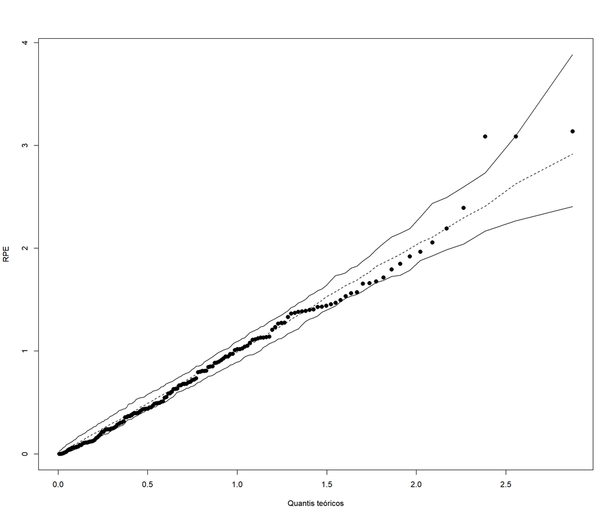

De acordo com o gráfico GQQ, podemos observar que apenas *uma* observação está fora da banda de confiança, portanto, não há fortes indícios de afastamento da normalidade.

> Conclusões parciais:
- O modelo não apresenta indícios de multicolinearidade conforme resultados obtidos no fator de inflação da variância (*Variance Inflation Factor - VIF*);
- É possível afirmarmos que **variâncias dos resíduos são homogêneas** (homocedasticidade), conforme resultados obtidos pelo Teste Goldfeld-Quandt;
- Os **resíduos não são autocorrelacionados**, conforme resultados obtidos no Teste de Durbin-Watson;
- **Pontos de alavanca**: As observações 1, 103, 131, 140, 144, 147, 152, 153 foram identificadas como pontos de alavanca, entretanto, podemos concluir que estes pontos são pouco influentes, tendo em vista que suas inferências não mudam após a remoção de cada uma das observações e os parâmetros continuam significativos;
- **Distância de Cook**: Identificamos que as observações 78, 85, 115, 127, 143, 147, 149, 150 como pontos influentes pela Distância de Cook, entretanto, através dos resultados obtidos na variação percentual dos coeficientes nota-se que estas não apresentam impacto expressivo no modelo, tendo em vista que suas inferências não mudam após a remoção de cada uma das observações e os parâmetros continuam significativos.
- Apesar de existir um ponto fora da banda de confiança no gráfico quantil-quantil, **não há fortes indícios de afastamento da normalidade**, desta forma, conclui-se que o **modelo está ajustado**, entretanto, pode ser melhorado.  
  Desta forma, após algumas tentativas de transformação do modelo ajustado, optou-se pela elaboração de um novo modelo, sob uma nova perspectiva e considerando outras variáveis.

### **3.3.2 Novo modelo ajustado**

Assim, analisando os atributos deste estudo, optou-se por criar uma variável *dummy* com a variável resposta $y$ = *Expectativa de vida saudável ao nascer*, de modo que:

$d =\{\begin{array}{c}1 = \text{nível de expectativa de vida alto;} \\ 0 = \text{nível de expectativa de vida baixo} \end{array}\;$

Desta forma, com intuito de levar em conta tal separação de níveis de $d =$ *dummy dos níveis de expectativa de vida saudável ao nascer* e considerando as variáveis $x_6 =$ *Apoio social*, $x_7 =$ *Liberdade para fazer escolhas de vida* e $x_9 =$ *Percepções de corrupção*, temos o modelo ajustado dado por:

$$\widehat{y}=40,686+18,005x_{i6}-6,567x_{i9}+12,256x_{i7}+20,647d_{i}-15,848(d_{i}*x_{i7})$$

Outras informações relevantes sobre o modelo ajustado são apresentadas a seguir:

```r
# Leitura dos dados
dados = read.table("expectativa2020.csv", header = TRUE, sep = ",")

dados = dados[,-c(1:2,13,16,20)]

colnames(dados)<-c(paste("x",1:6,sep=""),"y",paste("x",7:14,sep=""))

attach(dados)
n<-length(y)

# Variavel dummy
d<-ifelse(y>65,1,0)

modelo2 = lm(y~x6+x9+x7*d,data=dados)
summary(modelo2)
```

```
##
## Call:
## lm(formula = y ~ x6 + x9 + x7 * d, data = dados)
##
## Residuals:
##      Min       1Q   Median       3Q      Max
## -10.1507  -1.9222  -0.0791   1.9998   7.0322
##
## Coefficients:
##             Estimate Std. Error t value Pr(>|t|)
## (Intercept)   40.686      3.093  13.152  < 2e-16 ***
## x6            18.005      2.838   6.344 2.61e-09 ***
## x9            -6.567      1.624  -4.045 8.42e-05 ***
## x7            12.256      3.484   3.518 0.000579 ***
## d             20.647      3.617   5.708 6.11e-08 ***
## x7:d         -15.848      4.579  -3.461 0.000704 ***
## ---
## Signif. codes:  0 '***' 0.001 '**' 0.01 '*' 0.05 '.' 0.1 ' ' 1
##
## Residual standard error: 3.06 on 147 degrees of freedom
## Multiple R-squared:  0.8182, Adjusted R-squared:  0.812
## F-statistic: 132.3 on 5 and 147 DF,  p-value: < 2.2e-16
```

```r
p = 5+1
```

Considerando as estimativas encontradas, podemos afirmar que:

- $b_0$: Estima-se que, quando o *nível de expectativa de vida saudável ao nascer* for baixo $(d = 0)$ e o *apoio social* $(x_6)$, *liberdade para fazer escolhas de vida* $(x_7)$ e *percepções de corrupção* $(x_9)$ também forem iguais a zero, a *expectativa média de vida saudável ao nascer* $(y)$ é igual a $40,686$;
- $b_1$: Fixando as demais variáveis, estima-se que, para cada aumento em uma unidade do *apoio social* $(x_6)$, há um aumento de $18,005$ na *expectativa média de vida saudável ao nascer* $(y)$;
- $b_2$: Fixando as demais variáveis, estima-se que, para cada aumento em uma unidade nas *percepções de corrupção* $(x_9)$, há um decréscimo de $6,567$ na *expectativa média de vida saudável ao nascer* $(y)$;

> Interação
- Fixando as demais variáveis, quando o *nível de expectativa de vida saudável ao nascer* for baixo $(d = 0)$ e para cada aumento de uma unidade na *liberdade para fazer escolhas de vida* $(x_7)$, estima-se que, há um aumento de ($b_3$) $12,256$ na *expectativa média de vida saudável ao nascer* $(y)$;
- Fixando as demais variáveis, quando o *nível de expectativa de vida saudável ao nascer* for alto $(d = 1)$ e para cada aumento de uma unidade na *liberdade para fazer escolhas de vida* $(x_7)$, estima-se que, há um aumento médio de ($b_4$) $20,647$ no intercepto do modelo e uma diminuição média de ($b_5$) $-15,848$ na inclinação do hiperplano referente a variável *liberdade para fazer escolhas de vida* $(x_7)$. Dessa forma, há um decréscimo de $-3,592$ na *expectativa média de vida saudável ao nascer* $(y)$ para cada aumento de uma unidade na *liberdade para fazer escolhas de vida* $(x_7)$.

Conforme podemos observar também, o teste F resulta em um p-valor $< 2,2e^{-16}$, ou seja, pelo menos um parâmetro regressor é diferente de zero.  
Para o **teste de significância** leva-se em consideração, sob $H_0$, o teste de hipóteses dado $l = 0, 1, ... ,k$:

$$\\ H_0: \beta_l = 0$$

$$\\ H_1: \beta_l \neq 0$$

Considerando um nível de significância de 5%, os parâmetros do modelo são **todos** significativos $(< 0,05)$, ao passo que:

> p-valor = $2e-16 < 0,05 = α$

> p-valor = $2,61e-09 < 0,05 = α$

> p-valor = $8,42e-05 < 0,05 = α$

> p-valor = $0,000579 < 0,05 = α$

> p-valor = $6,11e-08 < 0,05 = α$

> p-valor = $0,000704 < 0,05 = α$

A mesma interpretação é válida caso considerássemos o nível de significância corrigido de Bonferroni (nível de significância real igual a $\alpha^* = 0,008333$).

Ao analisarmos o coeficiente de determinação ($R^2$), o modelo ajustado explica cerca de $81,82\%$ da variação total da variável *Expectativa de vida saudável ao nascer* ($y$). Também nota-se o resultado do $R^2$ *ajustado*, que representa a porcentagem de variação na resposta que é explicada pelo modelo, ajustada através do número de preditores do modelo em relação ao número de observações, que neste caso foi igual a $81,20\%$.

### **3.3.3 Análise de diagnóstico - Novo modelo**

### **3.3.3.1 Resíduos Padronizados Externamente (RPE)**

Inicialmente, fez-se a representação gráfica com o comportamento dos resíduos padronizados externamente (RPE) *versus* os índices:

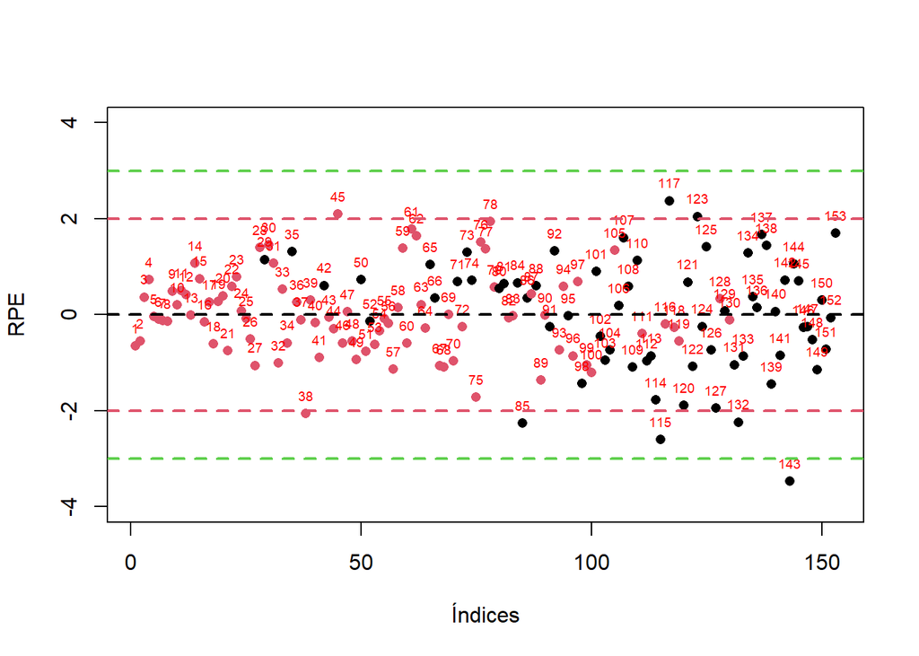

```r
# Análise dos resíduos
modelo2 = lm(y~x6+x9+x7*d,data=dados)
ajuste = modelo2

rpe<-rstudent(ajuste)

plot(rpe,pch=16,xlab="Índices",ylab="RPE",ylim=c(-4,4), col=d+1)
text(rpe,row.names(1:n),cex=0.6, pos=3,col="red")
abline(h=c(0,-2,2,-3,3),col=c(1,2,2,3,3),lty=2,lwd=2)
```

Podemos observar o comportamento dos resíduos no gráfico acima, que aparentemente estão distribuídos em torno do zero de forma aleatória e é notória a presença de apenas **um** ponto fora das faixas tracejadas dos limites: `[143]`.

Considerando que, conforme demonstrado anteriormente, existe *uma* observação que pode ser um outlier. Assim, é importante quantificarmos a influência destes nas estimativas do modelo e, para isso, calcula-se a variação percentual de cada estimativa dos coeficientes do modelo (sem o ponto observado) com relação às estimativas do modelo completo ajustado. Desta forma, foram calculadas as variações percentuais removendo o ponto identificado e foi feita a comparação dos impactos causados por essa remoção nas inferências dos parâmetros, obtendo-se os seguintes resultados:

```r
modelo2 = lm(y~x6+x9+x7*d,data=dados)
ajuste = modelo2

VariacaoPercentual_RPE2 <- function(){

# Removendo a observação [143]
mod1<-lm(y~x6+x9+x7*d,subset=c(1:142,144:n),data=dados)
m1 = summary(mod1)
r2_m1 = m1$r.squared
vp1 = 100*((coef(mod1)-coef(ajuste))/coef(ajuste))

b_0 = vp1[[1]]
b_1 = vp1[[2]]
b_2 = vp1[[3]]
b_3 = vp1[[4]]
b_4 = vp1[[5]]
b_5 = vp1[[6]]
observacao = "143"
R_2 = r2_m1
variacao = vp1

vp_comparacao = list(Resultados = data.frame(observacao,Var0=b_0,Var1=b_1,Var2=b_2,Var3=b_3,Var4=b_4,Var5=b_5,R_2))

return(vp_comparacao)
}
VariacaoPercentual_RPE2()
```

```
## $Resultados
##   observacao       Var0     Var1      Var2     Var3      Var4      Var5
## 1        143 -0.5139532 2.858841 -3.318972 -1.92513 -2.108385 -1.816042
##         R_2
## 1 0.8258226
```

```r
mod1<-lm(y~x6+x9+x7*d,subset=c(1:142,144:n),data=dados)
summary(mod1)
```

```
##
## Call:
## lm(formula = y ~ x6 + x9 + x7 * d, data = dados, subset = c(1:142,
##     144:n))
##
## Residuals:
##     Min      1Q  Median      3Q     Max
## -7.9257 -1.9054 -0.0838  1.8324  6.9615
##
## Coefficients:
##             Estimate Std. Error t value Pr(>|t|)
## (Intercept)   40.476      2.984  13.566  < 2e-16 ***
## x6            18.520      2.741   6.757 3.13e-10 ***
## x9            -6.349      1.567  -4.052 8.22e-05 ***
## x7            12.020      3.360   3.577 0.000472 ***
## d             20.212      3.491   5.790 4.14e-08 ***
## x7:d         -15.560      4.416  -3.523 0.000569 ***
## ---
## Signif. codes:  0 '***' 0.001 '**' 0.01 '*' 0.05 '.' 0.1 ' ' 1
##
## Residual standard error: 2.951 on 146 degrees of freedom
## Multiple R-squared:  0.8258, Adjusted R-squared:  0.8199
## F-statistic: 138.4 on 5 and 146 DF,  p-value: < 2.2e-16
```

> Conclusão: Conclui-se que a variação percentual em comparação com o modelo ajustado não é expressiva para o ponto identificado, bem como suas inferências não mudam após a remoção da observação e os parâmetros continuam significativos.

Também podemos visualizar o comportamento através da comparação entre o RPE *versus* as variáveis independentes, bem como o gráfico que relaciona o RPE *versus* os valores preditos:

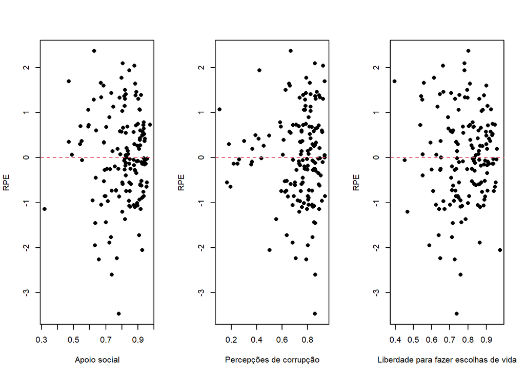

```r
par(mfrow=c(1,3))
plot(x6,rpe,xlab="Apoio social",ylab="RPE",pch=16)
abline(h=0,col=2,lty=2)
plot(x9,rpe,xlab="Percepções de corrupção",ylab="RPE",pch=16)
abline(h=0,col=2,lty=2)
plot(x7,rpe,xlab="Liberdade para fazer escolhas de vida",ylab="RPE",pch=16)
abline(h=0,col=2,lty=2)
```

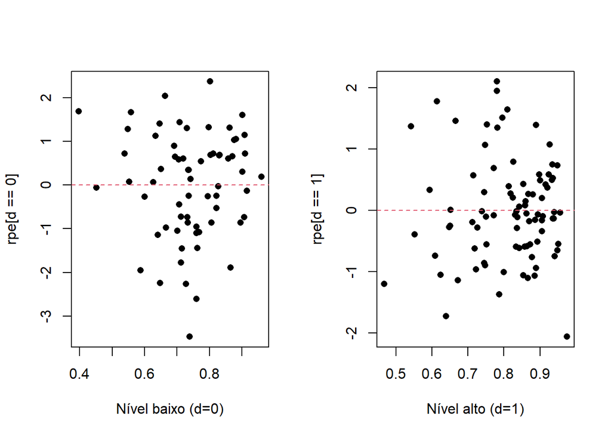

```r
par(mfrow=c(1,2))
plot(x7[d==0],rpe[d==0],xlab="Nível baixo (d=0)", pch=16)
abline(h=0,col=2,lty=2)
plot(x7[d==1],rpe[d==1],xlab="Nível alto (d=1)",pch=16)
abline(h=0,col=2,lty=2)
```

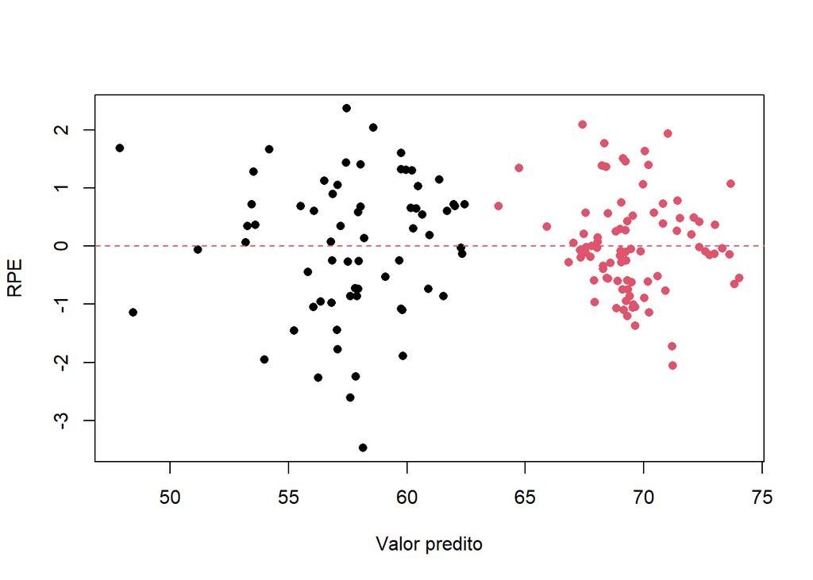

```r
modelo2 = lm(y~x6+x9+x7*d,data=dados)
ajuste = modelo2

# Resíduos x valor predito
plot(ajuste$fitted,rpe,ylab="RPE",xlab="Valor predito",pch=16, col=d+1)
abline(h=0,col=2,lty=2)
```

Ao analisarmos o comparativo entre os gráficos, é possível verificar que há um indicativo de que o comportamento dos resíduos não é o desejável, tendo em vista que há um certo padrão na distribuição dos pontos, principalmente no gráfico que relaciona os resíduos *versus* os valores preditos. Portanto, é importante verificarmos se as **variâncias do resíduos são homogêneas** e, para isso, utiliza-se o **Teste Goldfeld-Quandt**.

Neste teste serão consideradas as seguintes hipóteses, sob $H_0$:

$$\\ H_0: {\sigma^2_1}={\sigma^2_2}$$

$$\\ H_1: {\sigma^2_1}<{\sigma^2_2}$$

Considerando que $n=153$, o número de observações centrais removidas para a realização do teste será igual a $20\%$, então, $c_i = 0,2 * 153$, ou seja, $30,6$, a qual arredondaremos para $31$. Utilizou-se como base para identificar a heterocedasticidade a variável $x_9$ = *Percepções de corrupção*, sendo esta utilizada para ordenar os dados. Assim, os resultados obtidos no teste serão:

```r
modelo2 = lm(y~x6+x9+x7*d,data=dados)
ajuste = modelo2
n <-length(y)
c1 = n*0.2

# Considerando a variável x9
gqtest(ajuste,fraction=31,order.by = x9)
```

```
##
##  Goldfeld-Quandt test
##
## data:  ajuste
## GQ = 1.3544, df1 = 55, df2 = 55, p-value = 0.1319
## alternative hypothesis: variance increases from segment 1 to 2
```

Segundo o resultado obtido, considerando um nível de significância $α=0,05$, a hipótese nula não é rejeitada ($p−valor=0,1319 > 0,05=α$), assim, podemos afirmar que as variâncias dos resíduos são homogêneas, portanto, o **modelo apresenta homocedasticidade**.

Para verificar se existe algum tipo de **correlação (autocorrelação)** nos resíduos utiliza-se o **Teste de Durbin-Watson**.

```r
modelo2 = lm(y~x6+x9+x7*d,data=dados)
ajuste = modelo2
dwtest(ajuste)
```

```
##
##  Durbin-Watson test
##
## data:  ajuste
## DW = 1.985, p-value = 0.4172
## alternative hypothesis: true autocorrelation is greater than 0
```

Considerando um nível de significância $α = 0,05$, nota-se que $p−valor=0,4172>0,05=α$, portanto, não rejeitamos a hipótese nula e consequentemente não existe autocorrelação, portanto, podemos afirmar que com um nível de confiança de 95%, os **resíduos não são autocorrelacionados**.

Desta forma, podemos visualizar também o comportamento dos resíduos através do histograma:

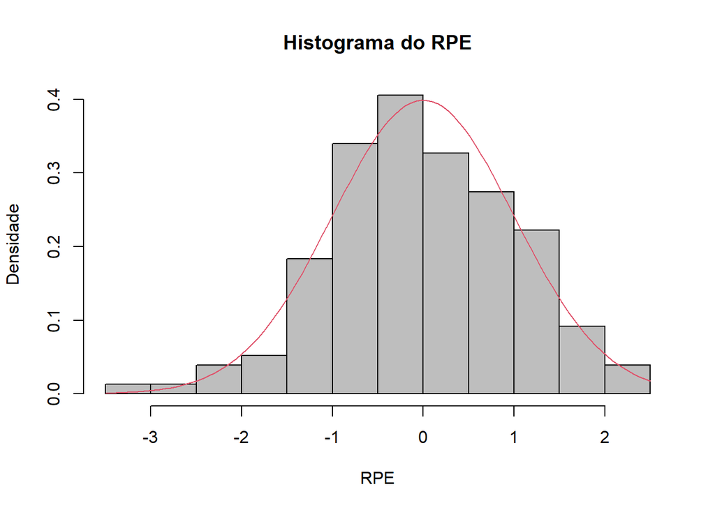

```r
hist(rpe,prob=T,xlab="RPE",ylab="Densidade", main="Histograma do RPE", col="gray")
curve(dnorm(x),add=T,col=2)
```

Conforme podemos observar, os erros seguem aproximadamente uma distribuição normal.

### **3.3.3.2 Pontos de alavanca**

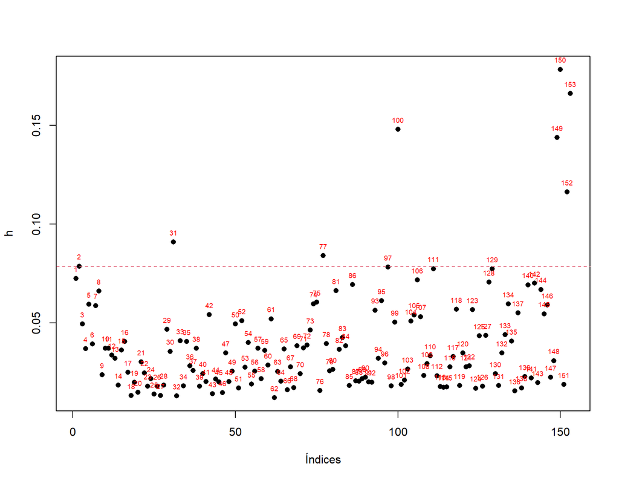

```r
modelo2 = lm(y~x6+x9+x7*d,data=dados)
ajuste = modelo2

n <-length(y)
p = 6
h<-lm.influence(ajuste)$hat
plot(h,pch=16, xlab="Índices")
text(h,row.names(1:n),cex=0.6, pos=3,col="red")
abline(h=2*(p/n),lty=2,col=2)
```

> Conclusão: As observações 31, 77, 100, 149, 150, 152, 153 podem ser pontos de alavanca

Considerando que, conforme demonstrado anteriormente, existem **sete** observações que podem ser pontos de alavanca, é importante quantificarmos a influência destes nas estimativas do modelo e, para isso, calcula-se a variação percentual de cada estimativa dos coeficientes do modelo (sem o ponto de alavanca observado) com relação às estimativas do modelo completo ajustado. Desta forma, foram calculadas as variações percentuais removendo cada observação que foi identificada e foi feita a comparação dos impactos causados por essa remoção nas inferências dos parâmetros, obtendo-se os seguintes resultados:

```r
modelo2 = lm(y~x6+x9+x7*d,data=dados)
ajuste = modelo2

VariacaoPercentual_Alavanca2 <- function(){

# Removendo a observação [31]
mod1<-lm(y~x6+x9+x7*d,subset=c(1:30:32:n),data=dados)
m1 = summary(mod1)
r2_m1 = m1$r.squared
vp1 = 100*((coef(mod1)-coef(ajuste))/coef(ajuste))

# Removendo a observação [77]
mod2<-lm(y~x6+x9+x7*d,subset=c(1:76,78:n),data=dados)
m2 = summary(mod2)
r2_m2 = m2$r.squared
vp2 = 100*((coef(mod2)-coef(ajuste))/coef(ajuste))

# Removendo a observação [100]
mod3<-lm(y~x6+x9+x7*d,subset=c(1:99,101:n),data=dados)
m3 = summary(mod3)
r2_m3 = m3$r.squared
vp3 = 100*((coef(mod3)-coef(ajuste))/coef(ajuste))

# Removendo a observação [149]
mod4<-lm(y~x6+x9+x7*d,subset=c(1:148,150:n),data=dados)
m4 = summary(mod4)
r2_m4 = m4$r.squared
vp4 = 100*((coef(mod4)-coef(ajuste))/coef(ajuste))

# Removendo a observação [150]
mod5<-lm(y~x6+x9+x7*d,subset=c(1:149,151:n),data=dados)
m5 = summary(mod5)
r2_m5 = m5$r.squared
vp5 = 100*((coef(mod5)-coef(ajuste))/coef(ajuste))

# Removendo a observação [152]
mod6<-lm(y~x6+x9+x7*d,subset=c(1:151,153:n),data=dados)
m6 = summary(mod6)
r2_m6 = m6$r.squared
vp6 = 100*((coef(mod6)-coef(ajuste))/coef(ajuste))

# Removendo a observação [153]
mod7<-lm(y~x6+x9+x7*d,subset=c(1:152),data=dados)
m7 = summary(mod7)
r2_m7 = m7$r.squared
vp7 = 100*((coef(mod7)-coef(ajuste))/coef(ajuste))


b_0 = c(vp1[[1]],vp2[[1]],vp3[[1]],vp4[[1]],vp5[[1]],vp6[[1]],vp7[[1]])
b_1 = c(vp1[[2]],vp2[[2]],vp3[[2]],vp4[[2]],vp5[[2]],vp6[[2]],vp7[[2]])
b_2 = c(vp1[[3]],vp2[[3]],vp3[[3]],vp4[[3]],vp5[[3]],vp6[[3]],vp7[[3]])
b_3 = c(vp1[[4]],vp2[[4]],vp3[[4]],vp4[[4]],vp5[[4]],vp6[[4]],vp7[[4]])
b_4 = c(vp1[[5]],vp2[[5]],vp3[[5]],vp4[[5]],vp5[[5]],vp6[[5]],vp7[[5]])
b_5 = c(vp1[[6]],vp2[[6]],vp3[[6]],vp4[[6]],vp5[[6]],vp6[[6]],vp7[[6]])
observacao = c("31", "77", "100", "149", "150", "152", "153")
R_2 = c(r2_m1,r2_m2,r2_m3,r2_m4,r2_m5,r2_m6,r2_m7)
variacao = c(vp1,vp2,vp3,vp4,vp5,vp6,vp7)

vp_comparacao = list(Resultados = data.frame(observacao,Var0=b_0,Var1=b_1,Var2=b_2,Var3=b_3,Var4=b_4,Var5=b_5,R_2))

return(vp_comparacao)
}
VariacaoPercentual_Alavanca2()
```

```
## $Resultados
##   observacao       Var0        Var1        Var2       Var3       Var4
## 1         31  0.0000000  0.00000000  0.00000000  0.0000000  0.0000000
## 2         77 -0.1652289 -0.39301617 -1.59917658  0.4035565 -4.8699319
## 3        100  0.5870006  0.63620079  4.73194440 -0.8796958  6.0166088
## 4        149  1.8824586 -6.57310075 -1.97772597  0.5075989 -0.9046089
## 5        150 -0.2716010  1.13643058 -2.39124316 -1.9192001 -1.1931510
## 6        152  0.1435423 -0.04551951  0.05649354 -0.5113168 -0.2314969
## 7        153 -4.5201633  3.06780447  2.34102274 16.1588265  8.2430766
##         Var5       R_2
## 1  0.0000000 0.8181987
## 2 -7.5314925 0.8189825
## 3  9.5464984 0.8199254
## 4 -2.4314863 0.8104815
## 5 -2.0132829 0.8180419
## 6 -0.3888714 0.8137263
## 7 14.3426142 0.8183124
```

### **3.3.3.3 Pontos de influência: Distância de Cook**

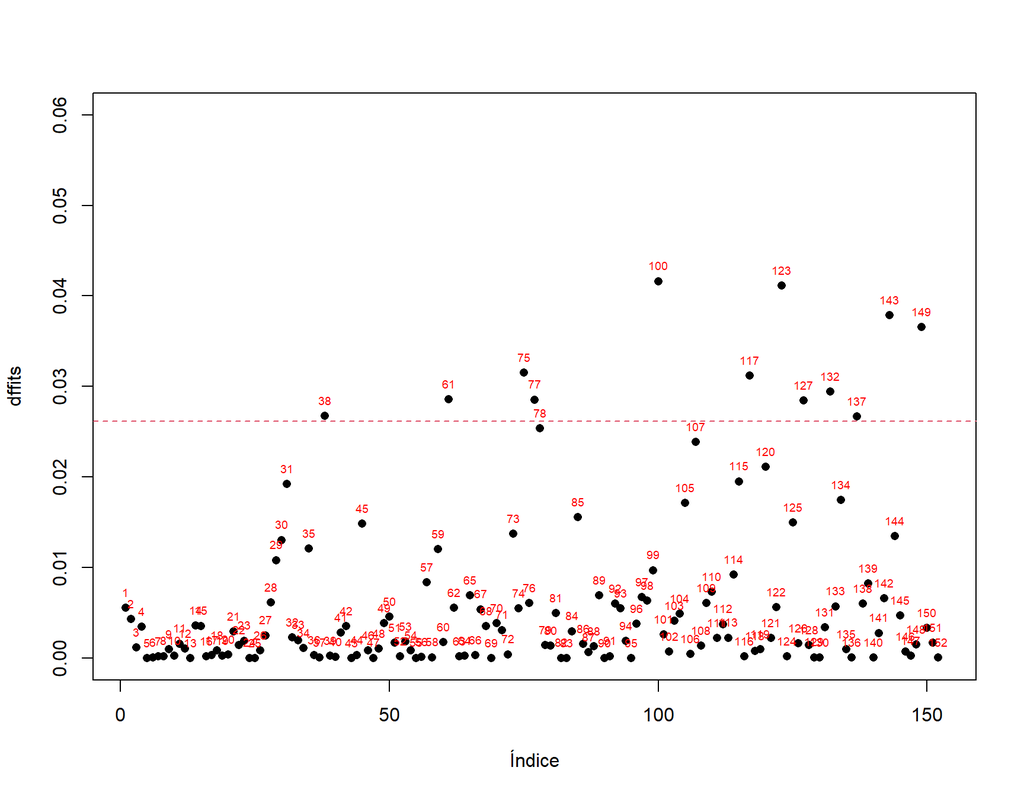

```r
ajuste = modelo2
# Distância de Cook
D_Cook = cooks.distance(ajuste)
plot(D_Cook,pch=16,xlab="Índice", ylab="dffits",ylim = c(0,0.06))
text(D_Cook,row.names(1:n),cex=0.6, pos=3,col="red")
abline(h=4/n, lty=2,col=2)
```

> Conclusão: Identificamos que as observações 38, 61, 75, 77, 100, 117, 123, 127, 132, 137, 143, 149 são pontos influentes pela Distância de Cook.

Considerando que, conforme demonstrado anteriormente, existem **doze** observações que podem ser pontos influentes pela Distância de Cook, é importante quantificarmos a influência destes nas estimativas do modelo e, para isso, calcula-se a variação percentual de cada estimativa dos coeficientes do modelo (sem o ponto de influência observado) com relação às estimativas do modelo completo ajustado. Desta forma, foram calculadas as variações percentuais removendo cada observação que foi identificada e foi feita a comparação dos impactos causados por essa remoção nas inferências dos parâmetros, obtendo-se os seguintes resultados:

```r
ajuste = modelo2

VariacaoPercentual_Cook2 <- function(){

# Removendo a observação [38]
mod1<-lm(y~x6+x9+x7*d,subset=c(1:37:39:n),data=dados)
m1 = summary(mod1)
r2_m1 = m1$r.squared
vp1 = 100*((coef(mod1)-coef(ajuste))/coef(ajuste))

# Removendo a observação [61]
mod2<-lm(y~x6+x9+x7*d,subset=c(1:60,62:n),data=dados)
m2 = summary(mod2)
r2_m2 = m2$r.squared
vp2 = 100*((coef(mod2)-coef(ajuste))/coef(ajuste))

# Removendo a observação [75]
mod3<-lm(y~x6+x9+x7*d,subset=c(1:74,76:n),data=dados)
m3 = summary(mod3)
r2_m3 = m3$r.squared
vp3 = 100*((coef(mod3)-coef(ajuste))/coef(ajuste))

# Removendo a observação [77]
mod4<-lm(y~x6+x9+x7*d,subset=c(1:76,78:n),data=dados)
m4 = summary(mod4)
r2_m4 = m4$r.squared
vp4 = 100*((coef(mod4)-coef(ajuste))/coef(ajuste))

# Removendo a observação [100]
mod5<-lm(y~x6+x9+x7*d,subset=c(1:99,101:n),data=dados)
m5 = summary(mod5)
r2_m5 = m5$r.squared
vp5 = 100*((coef(mod5)-coef(ajuste))/coef(ajuste))

# Removendo a observação [117]
mod6<-lm(y~x6+x9+x7*d,subset=c(1:116,118:n),data=dados)
m6 = summary(mod6)
r2_m6 = m6$r.squared
vp6 = 100*((coef(mod6)-coef(ajuste))/coef(ajuste))

# Removendo a observação [123]
mod7<-lm(y~x6+x9+x7*d,subset=c(1:122,124:n),data=dados)
m7 = summary(mod7)
r2_m7 = m7$r.squared
vp7 = 100*((coef(mod7)-coef(ajuste))/coef(ajuste))

# Removendo a observação [127]
mod8<-lm(y~x6+x9+x7*d,subset=c(1:126,128:n),data=dados)
m8 = summary(mod8)
r2_m8 = m8$r.squared
vp8 = 100*((coef(mod8)-coef(ajuste))/coef(ajuste))

# Removendo a observação [132]
mod9<-lm(y~x6+x9+x7*d,subset=c(1:131,133:n),data=dados)
m9 = summary(mod9)
r2_m9 = m9$r.squared
vp9 = 100*((coef(mod9)-coef(ajuste))/coef(ajuste))

# Removendo a observação [137]
mod10<-lm(y~x6+x9+x7*d,subset=c(1:136,138:n),data=dados)
m10 = summary(mod10)
r2_m10 = m10$r.squared
vp10 = 100*((coef(mod10)-coef(ajuste))/coef(ajuste))

# Removendo a observação [143]
mod11<-lm(y~x6+x9+x7*d,subset=c(1:142,144:n),data=dados)
m11 = summary(mod11)
r2_m11 = m11$r.squared
vp11 = 100*((coef(mod11)-coef(ajuste))/coef(ajuste))

# Removendo a observação [149]
mod12<-lm(y~x6+x9+x7*d,subset=c(1:148,150:n),data=dados)
m12 = summary(mod12)
r2_m12 = m12$r.squared
vp12 = 100*((coef(mod12)-coef(ajuste))/coef(ajuste))

b_0 = c(vp1[[1]],vp2[[1]],vp3[[1]],vp4[[1]],vp5[[1]],vp6[[1]],vp7[[1]],vp8[[1]],vp9[[1]],vp10[[1]],vp11[[1]],vp12[[1]])
b_1 = c(vp1[[2]],vp2[[2]],vp3[[2]],vp4[[2]],vp5[[2]],vp6[[2]],vp7[[2]],vp8[[2]],vp9[[2]],vp10[[2]],vp11[[2]],vp12[[2]])
b_2 = c(vp1[[3]],vp2[[3]],vp3[[3]],vp4[[3]],vp5[[3]],vp6[[3]],vp7[[3]],vp8[[3]],vp9[[3]],vp10[[3]],vp11[[3]],vp12[[3]])
b_3 = c(vp1[[4]],vp2[[4]],vp3[[4]],vp4[[4]],vp5[[4]],vp6[[4]],vp7[[4]],vp8[[4]],vp9[[4]],vp10[[4]],vp11[[4]],vp12[[4]])
b_4 = c(vp1[[5]],vp2[[5]],vp3[[5]],vp4[[5]],vp5[[5]],vp6[[5]],vp7[[5]],vp8[[5]],vp9[[5]],vp10[[5]],vp11[[5]],vp12[[5]])
b_5 = c(vp1[[6]],vp2[[6]],vp3[[6]],vp4[[6]],vp5[[6]],vp6[[6]],vp7[[6]],vp8[[6]],vp9[[6]],vp10[[6]],vp11[[6]],vp12[[6]])
observacao = c("38", "61", "75", "77", "100", "117", "123", "127", "132", "137", "143", "149")
R_2 = c(r2_m1,r2_m2,r2_m3,r2_m4,r2_m5,r2_m6,r2_m7,r2_m8,r2_m9,r2_m10,r2_m11,r2_m12)
variacao = c(vp1,vp2,vp3,vp4,vp5,vp6,vp7,vp8,vp9,vp10,vp11,vp12)

vp_comparacao = list(Resultados = data.frame(observacao,Var0=b_0,Var1=b_1,Var2=b_2,Var3=b_3,Var4=b_4,Var5=b_5,R_2))

return(vp_comparacao)

}

VariacaoPercentual_Cook2()
```

```
## $Resultados
##    observacao       Var0       Var1        Var2        Var3       Var4
## 1          38  0.0000000  0.0000000  0.00000000  0.00000000  0.0000000
## 2          61 -0.3957407  0.4247705 -2.12382953 -0.02917945 -4.8953770
## 3          75  0.3640221  2.2553908  5.25884708 -1.90191287  4.2311507
## 4          77 -0.1652289 -0.3930162 -1.59917658  0.40355645 -4.8699319
## 5         100  0.5870006  0.6362008  4.73194440 -0.87969585  6.0166088
## 6         117 -0.5632631  3.9964530 -2.82664867 -5.98301437 -2.4283919
## 7         123  0.2008059 -5.6508936  3.10061566  7.84743404  4.1996851
## 8         127  2.3551005 -0.7774031  0.07756524 -8.35017478 -4.1673357
## 9         132  1.5222393  2.9212057  2.78555611 -8.26027028 -3.3787118
## 10        137 -2.1159127 -0.5161570  0.04965289  9.33913770  4.4829280
## 11        143 -0.5139532  2.8588410 -3.31897200 -1.92512969 -2.1083853
## 12        149  1.8824586 -6.5731008 -1.97772597  0.50759886 -0.9046089
##         Var5       R_2
## 1   0.000000 0.8181987
## 2  -7.343963 0.8200486
## 3   6.851793 0.8217668
## 4  -7.531492 0.8189825
## 5   9.546498 0.8199254
## 6  -4.409698 0.8249534
## 7   5.428026 0.8232661
## 8  -6.675875 0.8163828
## 9  -4.423577 0.8200320
## 10  7.077163 0.8209087
## 11 -1.816042 0.8258226
## 12 -2.431486 0.8104815
```

### **3.3.3.4 Gráfico quantil-quantil**

O gráfico quantil-quantil (GQQ) é uma ferramenta importante para a análise de resíduos de modelos de regressão para verificar se os resíduos apresentam normalidade na distribuição. Deste modo, abaixo podemos verificar como fica o comportamento dos resíduos *versus* os quantis teóricos utilizando o modelo ajustado:

```r
ajuste = modelo2
hnp(ajuste,pch=16,cex=1.2,resid.type="student",xlab="Quantis teóricos",ylab="RPE")
```

```
## Gaussian model (lm object)
```

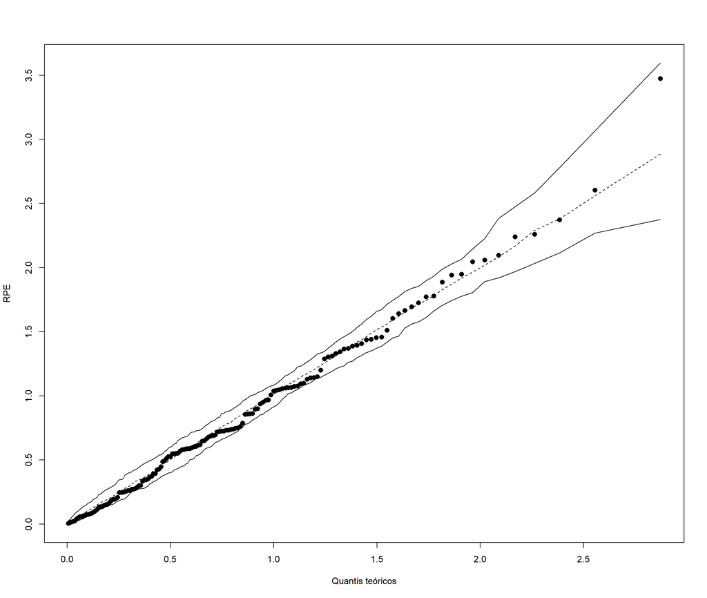

De acordo com o gráfico GQQ, ao visualizarmos a relação entre os quantis teóricos e o RPE, é possível verificar que todos os pontos encontram-se dentro da banda de confiança, o que nos mostra que **não há indícios de afastamentos da suposição de normalidade para os resíduos**.

## **4. Conclusão**

Portanto, pode-se concluir que os objetivos deste trabalho foram alcançados, e, diante ao exposto, podemos afirmar que o modelo **está bem ajustado** considerando os critérios *Apoio social*, *Liberdade para fazer escolhas de vida* e *Percepções de corrupção* sob a perspectiva de níveis relacionados a *expectativa de vida saudável ao nascer*.

## **5. Referências**

[1] Canal da Felicidade. *Relatório Mundial da Felicidade – Ranking dos países mais felizes*. 2020. Disponível em: https://canaldafelicidade.com.br/relatorio-mundial-da-felicidade. Acesso em: 09 nov. 2020.  
[2] Helliwell, J., et al. *World happiness report 2020*. New York: Sustainable Development Solutions Network. Saatavilla (2020). Disponível em: https://worldhappiness.report/ed/2020. Acesso em: 22 out. 2020.